# Cyclistic Bike Share

## About the Company

In 2016, Cyclistic launched a successful bike-share offering company in chicago. Since then, the program has grown to a fleet of 5,824 bicycles that are geotracked and locked into a network of 692 stations across Chicago. The bikes can be unlocked from one station and returned to any other station in the system anytime.

Until now, Cyclistic’s marketing strategy relied on building general awareness and appealing to broad consumer segments.One approach that helped make these things possible was the flexibility of its pricing plans: single-ride passes, full-day passes,and annual memberships. Customers who purchase single-ride or full-day passes are referred to as casual riders. Customers who purchase annual memberships are Cyclistic members.

## Questions for the analysis

- How do annual members and casual riders use Cyclistic bikes differently?
- Why would casual riders buy Cyclistic annual memberships?
- How can Cyclistic use digital media to influence casual riders to become members?

## In order to answer the key business questions, we will follow:

Data analysis phases: Prepare, Process, Analyze

## Business task

To analyze and identify trends in Cyclistic’s historical trip data to help Design marketing strategies build effective campaigns.

# Loading Packages

```r
library(tidyverse)
library(lubridate)
library(janitor)
library(stringr)
library(dplyr)
```

# Importing Data

```r
df1 <- read_csv("C:/Users/hp/Documents/Cyclistic Bike Share/All Data/202010-divvy-tripdata.csv")
df2 <- read_csv("C:/Users/hp/Documents/Cyclistic Bike Share/All Data/202011-divvy-tripdata.csv")
df3 <- read_csv("C:/Users/hp/Documents/Cyclistic Bike Share/All Data/202012-divvy-tripdata.csv")
df4 <- read_csv("C:/Users/hp/Documents/Cyclistic Bike Share/All Data/202101-divvy-tripdata.csv")
df5 <- read_csv("C:/Users/hp/Documents/Cyclistic Bike Share/All Data/202102-divvy-tripdata.csv")
df6 <- read_csv("C:/Users/hp/Documents/Cyclistic Bike Share/All Data/202103-divvy-tripdata.csv")
df7 <- read_csv("C:/Users/hp/Documents/Cyclistic Bike Share/All Data/202104-divvy-tripdata.csv")
df8 <- read_csv("C:/Users/hp/Documents/Cyclistic Bike Share/All Data/202105-divvy-tripdata.csv")
df9 <- read_csv("C:/Users/hp/Documents/Cyclistic Bike Share/All Data/202106-divvy-tripdata.csv")
df10 <- read_csv("C:/Users/hp/Documents/Cyclistic Bike Share/All Data/202107-divvy-tripdata.csv")
df11 <- read_csv("C:/Users/hp/Documents/Cyclistic Bike Share/All Data/202108-divvy-tripdata.csv")
df12 <- read_csv("C:/Users/hp/Documents/Cyclistic Bike Share/All Data/202109-divvy-tripdata.csv")
```

# Joining Data

```r
bike_rides <- rbind(df1,df2,df3,df4,df5,df6,df7,df8,df9,df10,df11,df12)
bike_rides <- remove_empty(bike_rides,which= c("cols"))
bike_rides <- remove_empty(bike_rides,which= c("rows"))

head(bike_rides)
```

```
## # A tibble: 6 x 13
##   ride_id rideable_type started_at          ended_at            start_station_n~
##   <chr>   <chr>         <dttm>              <dttm>              <chr>
## 1 ACB6B4~ electric_bike 2020-10-31 19:39:43 2020-10-31 19:57:12 Lakeview Ave & ~
## 2 DF450C~ electric_bike 2020-10-31 23:50:08 2020-11-01 00:04:16 Southport Ave &~
## 3 B6396B~ electric_bike 2020-10-31 23:00:01 2020-10-31 23:08:22 Stony Island Av~
## 4 44A4AE~ electric_bike 2020-10-31 22:16:43 2020-10-31 22:19:35 Clark St & Grac~
## 5 10B7DD~ electric_bike 2020-10-31 19:38:19 2020-10-31 19:54:32 Southport Ave &~
## 6 DA6C37~ electric_bike 2020-10-29 17:38:04 2020-10-29 17:45:43 Larrabee St & D~
## # ... with 8 more variables: start_station_id <chr>, end_station_name <chr>,
## #   end_station_id <chr>, start_lat <dbl>, start_lng <dbl>, end_lat <dbl>,
## #   end_lng <dbl>, member_casual <chr>
```

# Cleaning and Processing Data

#### Changing the date formats

```r
bike_rides$started_at <- ymd_hms(bike_rides$started_at)
bike_rides$ended_at <- ymd_hms(bike_rides$ended_at)

head(bike_rides)
```

```
## # A tibble: 6 x 13
##   ride_id rideable_type started_at          ended_at            start_station_n~
##   <chr>   <chr>         <dttm>              <dttm>              <chr>
## 1 ACB6B4~ electric_bike 2020-10-31 19:39:43 2020-10-31 19:57:12 Lakeview Ave & ~
## 2 DF450C~ electric_bike 2020-10-31 23:50:08 2020-11-01 00:04:16 Southport Ave &~
## 3 B6396B~ electric_bike 2020-10-31 23:00:01 2020-10-31 23:08:22 Stony Island Av~
## 4 44A4AE~ electric_bike 2020-10-31 22:16:43 2020-10-31 22:19:35 Clark St & Grac~
## 5 10B7DD~ electric_bike 2020-10-31 19:38:19 2020-10-31 19:54:32 Southport Ave &~
## 6 DA6C37~ electric_bike 2020-10-29 17:38:04 2020-10-29 17:45:43 Larrabee St & D~
## # ... with 8 more variables: start_station_id <chr>, end_station_name <chr>,
## #   end_station_id <chr>, start_lat <dbl>, start_lng <dbl>, end_lat <dbl>,
## #   end_lng <dbl>, member_casual <chr>
```

#### Adding more columns Ride length, Day of week, Year, month and Ride duration

```r
bike_rides <- bike_rides %>% mutate(Ride_length = seconds_to_period(ended_at-started_at))
bike_rides <- bike_rides %>% mutate(Day_of_week = wday(started_at))
bike_rides <- bike_rides %>% mutate(Year = year(started_at))
bike_rides <- bike_rides %>% mutate(Month = month.abb[month(started_at)])
bike_rides <- bike_rides %>% mutate(Ride_duration = (ended_at-started_at))

head(bike_rides)
```

```
## # A tibble: 6 x 18
##   ride_id rideable_type started_at          ended_at            start_station_n~
##   <chr>   <chr>         <dttm>              <dttm>              <chr>
## 1 ACB6B4~ electric_bike 2020-10-31 19:39:43 2020-10-31 19:57:12 Lakeview Ave & ~
## 2 DF450C~ electric_bike 2020-10-31 23:50:08 2020-11-01 00:04:16 Southport Ave &~
## 3 B6396B~ electric_bike 2020-10-31 23:00:01 2020-10-31 23:08:22 Stony Island Av~
## 4 44A4AE~ electric_bike 2020-10-31 22:16:43 2020-10-31 22:19:35 Clark St & Grac~
## 5 10B7DD~ electric_bike 2020-10-31 19:38:19 2020-10-31 19:54:32 Southport Ave &~
## 6 DA6C37~ electric_bike 2020-10-29 17:38:04 2020-10-29 17:45:43 Larrabee St & D~
## # ... with 13 more variables: start_station_id <chr>, end_station_name <chr>,
## #   end_station_id <chr>, start_lat <dbl>, start_lng <dbl>, end_lat <dbl>,
## #   end_lng <dbl>, member_casual <chr>, Ride_length <Period>,
## #   Day_of_week <dbl>, Year <dbl>, Month <chr>, Ride_duration <drtn>
```

#### Finding min, max and mean

```r
Min_Bike_Rides <- min(bike_rides$Ride_length)
Mean_Bike_Rides <- mean(bike_rides$Ride_length)
Max_Bike_Rides <- max(bike_rides$Ride_length)

Min_Bike_Rides
```

```
## [1] -59
```

```r
Mean_Bike_Rides
```

```
## [1] 29.33347
```

```r
Max_Bike_Rides
```

```
## [1] 59
```

## Analysing Data

#### Mean ride length on membership and yearly basis

```r
bike_rides_result <- bike_rides %>% select(member_casual,Ride_length,Year) %>%
group_by(member_casual,Year) %>% summarise(Avg_ride_length = mean(Ride_length))

bike_rides_result
```

```
## # A tibble: 4 x 3
## # Groups:   member_casual [2]
##   member_casual  Year Avg_ride_length
##   <chr>         <dbl>           <dbl>
## 1 casual         2020            29.2
## 2 casual         2021            29.4
## 3 member         2020            29.1
## 4 member         2021            29.4
```

#### Number of rides on membership and weekly basis

```r
bike_rides_result1 <- bike_rides %>% select(member_casual,Ride_length,Day_of_week) %>%
group_by(member_casual,Day_of_week) %>% summarise(Number_of_rides = n())

bike_rides_result1
```

```
## # A tibble: 14 x 3
## # Groups:   member_casual [2]
##    member_casual Day_of_week Number_of_rides
##    <chr>               <dbl>           <int>
##  1 casual                  1          445046
##  2 casual                  2          266450
##  3 casual                  3          251589
##  4 casual                  4          257230
##  5 casual                  5          274692
##  6 casual                  6          339405
##  7 casual                  7          523875
##  8 member                  1          345300
##  9 member                  2          375860
## 10 member                  3          407167
## 11 member                  4          422849
## 12 member                  5          420567
## 13 member                  6          405936
## 14 member                  7          400295
```

#### Number of rides on weekly basis

```r
bike_rides_result2 <- bike_rides %>% select(member_casual,Ride_length,Day_of_week) %>%
group_by(Day_of_week) %>% summarise(Number_of_rides = n())

bike_rides_result2
```

```
## # A tibble: 7 x 2
##   Day_of_week Number_of_rides
##         <dbl>           <int>
## 1           1          790346
## 2           2          642310
## 3           3          658756
## 4           4          680079
## 5           5          695259
## 6           6          745341
## 7           7          924170
```

#### Summarizing the trip duration

```r
bike_rides_result4 <- bike_rides %>% select(Day_of_week,Ride_duration,member_casual) %>%
group_by(Day_of_week,member_casual) %>% summarise(Trip_Duration = quantile(minute(seconds_to_period(Ride_duration)),
prob = c(0.15,0.25,0.5,0.75,0.85)))
```

## Converting Data from Longer to wider format

```r
bike_rides_result <- bike_rides_result %>%
pivot_wider(names_from  = Year, values_from = Avg_ride_length)

bike_rides_result
```

```
## # A tibble: 2 x 3
## # Groups:   member_casual [2]
##   member_casual `2020` `2021`
##   <chr>          <dbl>  <dbl>
## 1 casual          29.2   29.4
## 2 member          29.1   29.4
```

```r
bike_rides_result1 <- bike_rides_result1 %>%
pivot_wider(names_from  = Day_of_week, values_from = Number_of_rides)

bike_rides_result1
```

```
## # A tibble: 2 x 8
## # Groups:   member_casual [2]
##   member_casual    `1`    `2`    `3`    `4`    `5`    `6`    `7`
##   <chr>          <int>  <int>  <int>  <int>  <int>  <int>  <int>
## 1 casual        445046 266450 251589 257230 274692 339405 523875
## 2 member        345300 375860 407167 422849 420567 405936 400295
```

```r
bike_rides_result2 <- bike_rides_result2 %>%
pivot_wider(names_from  = Day_of_week, values_from = Number_of_rides)

bike_rides_result2
```

```
## # A tibble: 1 x 7
##      `1`    `2`    `3`    `4`    `5`    `6`    `7`
##    <int>  <int>  <int>  <int>  <int>  <int>  <int>
## 1 790346 642310 658756 680079 695259 745341 924170
```

# Visualization

#### Yearly Analysis for Casual vs Annual membership

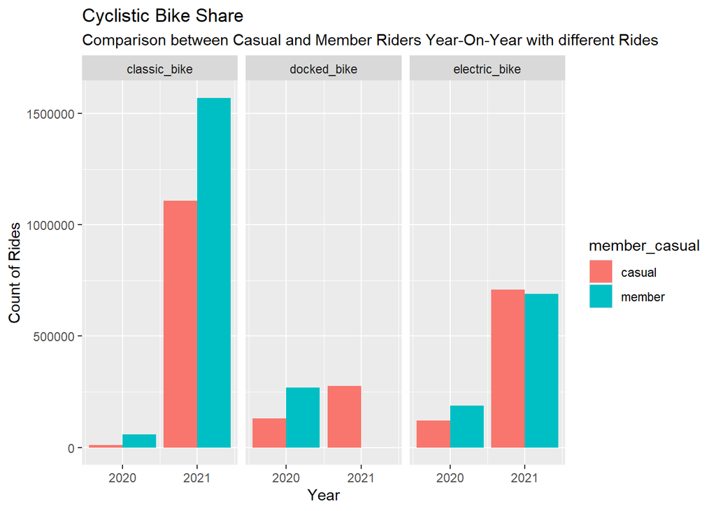

```r
ggplot(data = bike_rides)+
geom_bar(mapping= aes(x= Year,fill=member_casual),position="dodge") +
scale_x_continuous(breaks = c(2020,2021))+
facet_wrap(~rideable_type)+
labs(title="Cyclistic Bike Share" , subtitle= "Comparison between Casual and Member Riders Year-On-Year with different Rides", y = "Count of Rides")
```

#### Monthly Analysis for Casual vs Annual membership

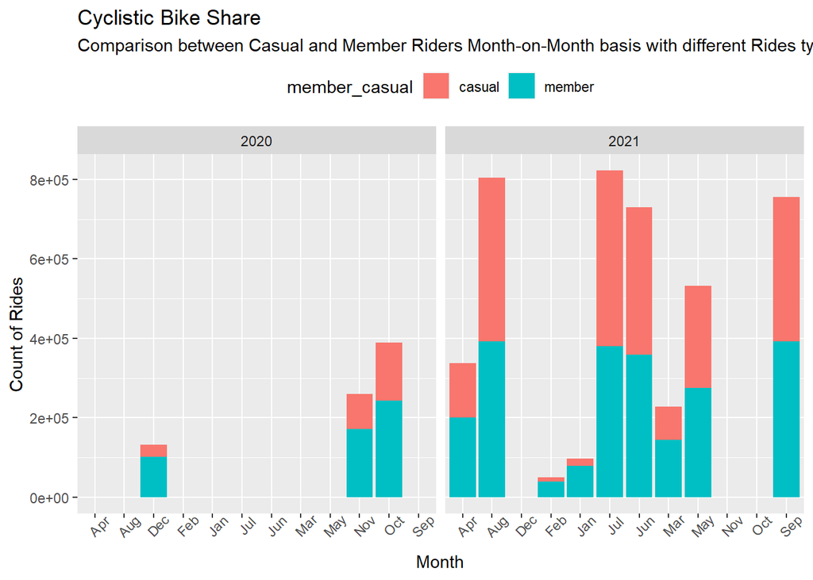

```r
ggplot(data = bike_rides)+
geom_bar(mapping= aes(x= Month,fill=member_casual)) +
theme(legend.position = "top",axis.text.x = element_text(angle = 45))+
labs(title="Cyclistic Bike Share" , subtitle= "Comparison between Casual and Member Riders Month-on-Month basis with different Rides type", y = "Count of Rides")+
facet_wrap(~Year)
```

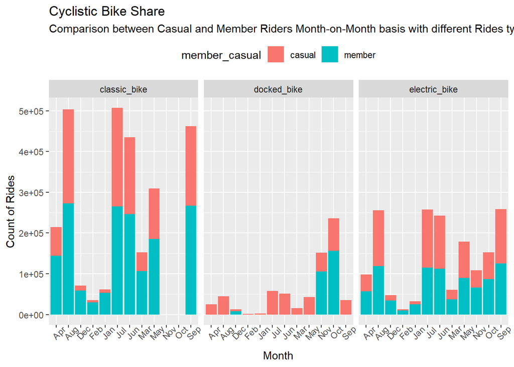

```r
ggplot(data = bike_rides)+
geom_bar(mapping= aes(x= Month,fill=member_casual)) +
theme(legend.position = "top",axis.text.x = element_text(angle = 45))+
labs(title="Cyclistic Bike Share" , subtitle= "Comparison between Casual and Member Riders Month-on-Month basis with different Rides type", y = "Count of Rides")+
facet_wrap(~rideable_type)
```

#### Weekly analysis for Casual vs Annual membership

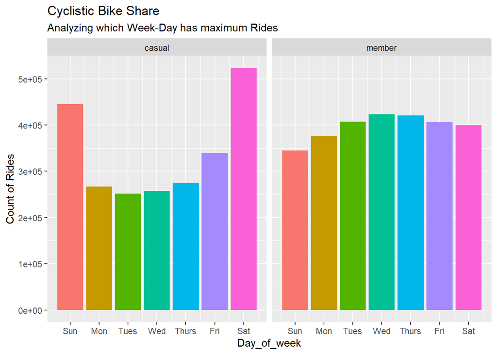

```r
ggplot(data = bike_rides)+
geom_bar(mapping= aes(x= Day_of_week,fill = factor(Day_of_week))) + theme(legend.position="none")+
facet_wrap(~member_casual) + scale_x_continuous(breaks = c(1:7),
labels = c("Sun","Mon","Tues","Wed","Thurs","Fri","Sat"))+
labs(title="Cyclistic Bike Share" , subtitle= "Analyzing which Week-Day has maximum Rides", y = "Count of Rides")
```

#### Trip duration weekly analysis

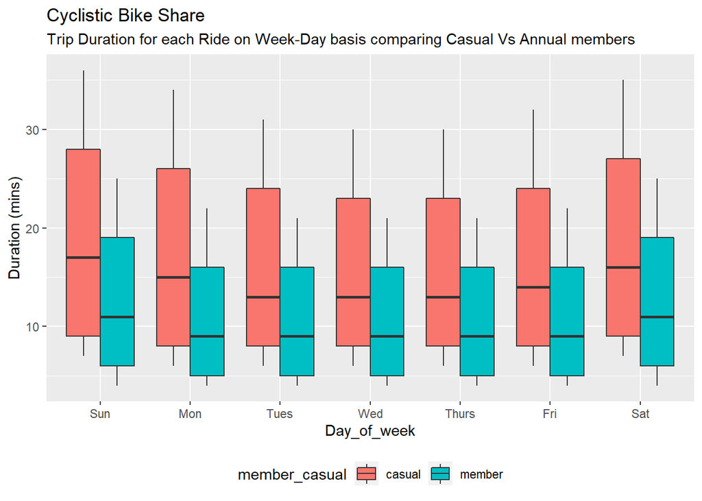

```r
ggplot(data = bike_rides_result4)+
geom_boxplot(mapping= aes(x= factor(Day_of_week), y=Trip_Duration, fill=member_casual),position="dodge") +
theme(legend.position="bottom")+
scale_x_discrete(breaks = c(1:7),labels = c("Sun","Mon","Tues","Wed","Thurs","Fri","Sat")) +
labs(title="Cyclistic Bike Share" , subtitle= "Trip Duration for each Ride on Week-Day basis comparing Casual Vs Annual members", x="Day_of_week" ,y = "Duration (mins)")
```